# testing_code_1

## Chapter 2 Methodology and Framework of Analysis

```
'0.13.1'
```

toggle input

[output not shown]

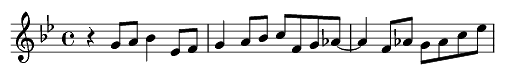

[figure not shown]

### 2.2 Data Prep

The data preparation had 3 steps:

- Converting the files from musicXML
- Creating a data frame
- Performing some basic calculations on the data to ascertain, previous note, resolution note

Create dataframes for each solo and then append them into the larger data set

### 2.3 Characteristics of the Dataset

Each solo transcription is converted to a data set where each note of the solo has its own row of data. Table 2.1. shows a row of data for each note in Figure 2.2

|  | location | note | part | root | third | fifth | seventh | measure | prep | res | p_offset | r_offset | chord_type | dist_note_to_root | name |
| --- | --- | --- | --- | --- | --- | --- | --- | --- | --- | --- | --- | --- | --- | --- | --- |
| 0 | 1.0 | 70 | 0 | 55 | 58 | 61 | 65 | 1.250 | NaN | -2 | NaN | 1.0 | minor_seventh_flat_five | 3 | All The Things You Are |
| 1 | 2.0 | 68 | 0 | 55 | 58 | 61 | 65 | 1.500 | 2 | 4 | 1.0 | 2.0 | minor_seventh_flat_five | 1 | All The Things You Are |
| 2 | 4.0 | 72 | 0 | 55 | 64 | 61 | 70 | 2.000 | -4 | -5 | 2.0 | 1.5 | not_determined | 5 | All The Things You Are |
| 3 | 5.5 | 67 | 0 | 60 | 64 | 67 | 70 | 2.375 | 5 | -2 | 1.5 | 0.5 | dominant_seventh | 7 | All The Things You Are |

**1. Location:**

Location is a measure of time and describes how many quarternotes any particular note is from the beginning a particular solo

**2. Note:**

The midi frequency of a each note in the solo.

**3. Part:**

The score originally contained 5 parts (one for the solo, one for the fifth, seventh, third and root. Although it is not used in the analysis it has been kept in the data set for future work where analysis is across a number of parts

**4. Root:**

The midi frequency of the root note of chord over which the solo note is being played

**5. Third:**

The midi frequency of the third chord over which the solo note is being played

**6. Fifth:**

The midi frequency of the fifth of the chord over which the solo note is being played

**7. Seventh:**

The midi frequency of the seventh of chord over which the solo note is being played

**8. Measure:**

The measure (and exact location within that measure) of any given note in a solo

**9. Prep:**

The distance between midi frequency of a note in a row of data, and the note in the previous row of data

**10. Res:**

The distance between midi frequency of a note in a row of data, and the note in the next row of data

**11. P_offset:**

This is a measure of time, being distance in quarter notes between a note in a row or data, and the note in the previous row of data. It is used to ascertain whether the previous note is part of same phrase as the currrent note

**12. R_offset:**

This is a measure of time, being distance in quarter notes between a note in a row or data, and the note in a note in the row of data. It is used to ascertain whether the next note is part of same phrase as the currrent note

**13. Chord Type:**

Calculated by examining the distance between the frequencies of the root, third, fifth and seventh and assigning an appropriately named chord

**14. Dist_note_to_root:**

The distance between the midi frequency of the note of the solo and the midi frequency of the root. This is an absolute value and calculated modulo 12

**15. Current Tempo**

An approximation, calculated from the recording

**16. Name:**

The name of the song from which the solo is taken

The data set is also indexed (0:7858) and each record is given a sequential number. This is a default of the Data Frame structure but also allows analysis of how melody construction changs over time. The order of the data set also reflects the order in which these pieces were recorded so each record refers to a later point in time

### 2.4 Framework for analysis

There are some things that come out and are immedidtely evident in the data

Ubiquitious nature of chords and fluidity

Tendency of step wise motion

Arpeggio based patterns

The position on the beat means somehting

Nomenclature

## Chapter 3 Harmonic Analysis

|  | location | note | part | root | third | fifth | seventh | measure | prep | res | p_offset | r_offset | dist_note_to_root |
| --- | --- | --- | --- | --- | --- | --- | --- | --- | --- | --- | --- | --- | --- |
| count | 7858.000000 | 7858.000000 | 7858 | 7858.000000 | 7858.000000 | 7858.000000 | 7858.000000 | 7858.000000 | 7853.000000 | 7853.000000 | 7853.000000 | 7853.000000 | 7858.000000 |
| mean | 487.630360 | 70.103080 | 0 | 59.118733 | 62.766862 | 65.916391 | 69.436243 | 122.907590 | -0.000127 | 0.000127 | 0.578613 | 0.578613 | 5.358488 |
| std | 292.757246 | 6.276381 | 0 | 3.588163 | 3.581678 | 3.602780 | 3.609601 | 73.189311 | 3.638340 | 3.638340 | 0.679753 | 0.679753 | 3.446626 |
| min | 0.000000 | 46.000000 | 0 | 51.000000 | 56.000000 | 59.000000 | 62.000000 | 1.000000 | -31.000000 | -20.000000 | 0.083333 | 0.083333 | 0.000000 |
| 25% | 258.500000 | 66.000000 | 0 | 56.000000 | 60.000000 | 63.000000 | 67.000000 | 65.625000 | -2.000000 | -2.000000 | 0.333333 | 0.333333 | 2.000000 |
| 50% | 469.000000 | 70.000000 | 0 | 58.000000 | 62.000000 | 65.000000 | 69.000000 | 118.250000 | 0.000000 | 0.000000 | 0.500000 | 0.500000 | 5.000000 |
| 75% | 695.500000 | 74.000000 | 0 | 63.000000 | 66.000000 | 69.000000 | 73.000000 | 174.875000 | 2.000000 | 2.000000 | 0.500000 | 0.500000 | 8.000000 |
| max | 1159.500000 | 89.000000 | 0 | 65.000000 | 69.000000 | 72.000000 | 76.000000 | 290.875000 | 20.000000 | 31.000000 | 11.500000 | 11.500000 | 11.000000 |

8 rows × 13 columns

### 3.1 General Remarks About The Data Set

```
72    607
67    561
70    552
68    501
74    501
75    479
65    428
63    368
69    368
73    322
77    320
62    304
71    304
66    252
79    245
```

[output cut: 29 more lines]

```
count     43.000000
mean     182.744186
std      188.523725
min        1.000000
25%       19.000000
50%      119.000000
75%      312.000000
max      607.000000
dtype: float64
```

As well as examing occurences of discrete frequencies, it is also possible to look at the notes themselves, regardless of the octave in which they appear. This data (seen in Figure 3.1) shows that there are some midi frequencies (such as Eb, C, G and D) which occur more approximately twice as much as other notes (B, F#, E and C#)

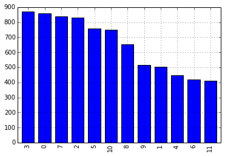

One hypothesis to explain this may be that it is simply due to the choice of tonality jazz standards usually employ (such as the tonality of F Major, Bb Major etc.). Key centres of, for example, B Major and E major are less common in jazz. This suggests there is some kind of relationship between the notes in solos and the notes of the harmony. Anecdotally this is the case, but its worth noting that the data supports this. Figure 3.2 shows a count of how frequenctly each note in the octave occurs in the harmony and there is a relationship that can be seen between the commonly occuring notes in the harmony and the commonly occuring notes in the solo

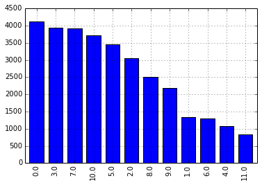

The relationship between notes of the harmony and the notes of the solo becomes more pronounced when looking at individiual solos in the dataset and this can in Figure 3.3

The data set also shows which chords in the harmony are most common. Table 2.3 and Figure 3.4 shows that in the data set, the occurence of dominant seventh chord is most likely chord that a note in the solo is being played along side with

```
dominant_seventh           0.359124
major_seventh              0.279588
minor_seventh              0.197251
minor_seventh_flat_five    0.108043
not_determined             0.055994
dtype: float64
```

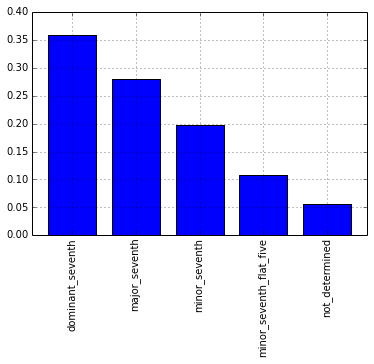

[output not shown]

Table 3.3

| Degree Number | Degree Name |
| --- | --- |
| 0 | root |
| 1 | flat ninth |
| 2 | ninth |
| 3 | sharp ninth |
| 4 | major third |
| 5 | eleventh |
| 6 | sharp eleventh |
| 7 | fifth |
| 8 | flat thirteenth |
| 9 | thirteenth |
| 10 | flat seventh |
| 11 | major seventh |

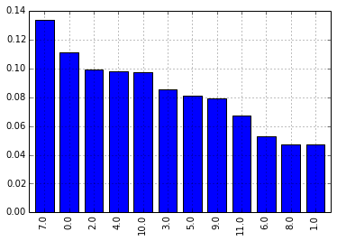

### 3.2 The Dominant Seventh Chord

Degree choice on the dominant seventh chord

```
0     351
10    344
7     342
4     313
9     245
2     236
1     203
5     198
3     177
8     167
6     134
11    112
dtype: int64
```

```
0     0.124380
10    0.121899
7     0.121191
4     0.110914
9     0.086818
2     0.083629
1     0.071935
5     0.070163
3     0.062721
8     0.059178
6     0.047484
11    0.039688
dtype: float64
```

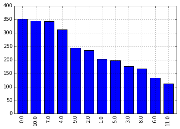

[output not shown]

7858 rows × 15 columns

[output not shown]

[output not shown]

[output not shown]

[output cut: 17 more lines]

[figure not shown]

[figure not shown]

[figure not shown]

[figure not shown]

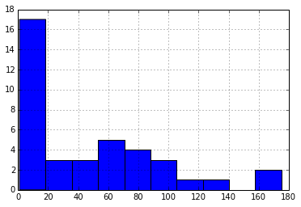

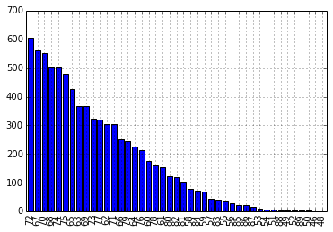

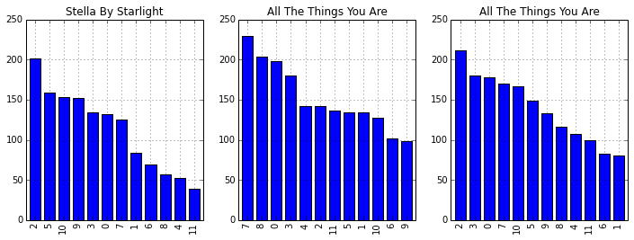

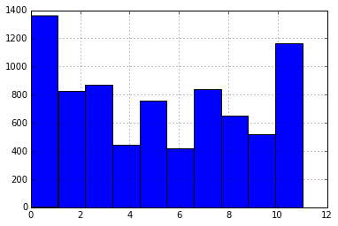

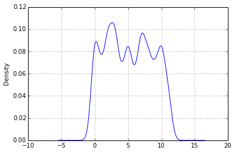

[output not shown]

[interactive chart not shown]